# IMT 573: Problem Set 4 - Data Analysis - Soutions

Kulraj Singh Kohli

Due: Wednesday, October 30, 2019, 3pm

##### Collaborators:

Harpreet Singh ##### Instructions:

Before beginning this assignment, please ensure you have access to R and RStudio; this can be on your own personal computer or on the IMT 573 R Studio Server (note: the updated url is ).

1. Download the `problemset4.rmd` file from Canvas or save a copy to your local directory on RStudio Server. Open `problemset4.rmd` in RStudio and supply your solutions to the assignment by editing `problemset4.rmd`.
2. Replace the “Insert Your Name Here” text in the `author:` field with your own full name. Any collaborators must be listed on the top of your assignment.
3. Be sure to include well-documented (e.g. commented) code chucks, figures, and clearly written text chunk explanations as necessary. Any figures should be clearly labeled and appropriately referenced within the text. Be sure that each visualization adds value to your written explanation; avoid redundancy – you do no need four different visualizations of the same pattern.
4. Collaboration on problem sets is fun and useful, and we encourage it, but each student must turn in an individual write-up in their own words as well as code/work that is their own. Regardless of whether you work with others, what you turn in must be your own work; this includes code and interpretation of results. The names of all collaborators must be listed on each assignment. Do not copy-and-paste from other students’ responses or code.
5. All materials and resources that you use (with the exception of lecture slides) must be appropriately referenced within your assignment.
6. Remember partial credit will be awarded for each question for which a serious attempt at finding an answer has been shown. Students are encouraged to attempt each question and to document their reasoning process even if they cannot find the correct answer. If you would like to include R code to show this process, but it does not run withouth errors you can do so with the `eval=FALSE` option.
7. When you have completed the assignment and have **checked** that your code both runs in the Console and knits correctly when you click `Knit PDF`, rename the knitted PDF file to `ps4_ourLastName_YourFirstName.pdf`, and submit the PDF file on Canvas.

##### Setup

In this problem set you will need, at minimum, the following R packages.

```r
# Load standard libraries
library(tidyverse)
library(gridExtra)
library(readr)
library(dplyr)
library(purrr)
library(datasets)
library(ggplot2)
```

### Problem 1: 50 States in the USA

In this problem we will use the `state` dataset, available as part of the R statistical computing platforms. This data is related to the 50 states of the United States of America. Load the data and use it to answer the following questions.

##### (a) Describe the data and each variable it contains.

state.abb - Character vector of 2-letter abbreviations for the state names.

state.area - Numeric vector of state areas (in square miles).

state.center - List with components named x and y giving the approximate geographic center of each state in negative longitude and latitude. Alaska and Hawaii are placed just off the West Coast.

state.division - Factor giving state divisions (New England, Middle Atlantic, South Atlantic, East South Central, West South Central, East North Central, West North Central, Mountain, and Pacific).

state.name - Character vector giving the full state names.

Income: Per capita income (1974)

Illiteracy: Illiteracy (1970, percent of population)

Life Exp: Life expectancy in years (1969–71)

Murder: Murder and non-negligent manslaughter rate per 100,000 population (1976)

HS Grad: Percent high-school graduates (1970) Frost: Mean number of days with minimum temperature below freezing (1931–1960) in capital or large city Area: Land area in square miles Convert it into a tidy data frame preparing it for analysis.

```r
#converting state.x77 as tidy data for analysis
state_table <- as_tibble(state.x77)
```

state.x77 seems to have alot of valuable information missing. Such as Name and the location of the state. We can add these using the other vectors above. We see there are 2 different types of area in the information, the one in the table is land area and the one in state.area is the overall area. For the purpose of this analysis I am gonna stick with the land area of the state.

##Building our final table for analysis by adding additional columns

```r
#making state.center into a table for ease of merging
center<-as_tibble(state.center)

state_table<- state_table %>% mutate(Name = state.name, Longitude = center$x, Latitude = center$y, Region= state.region,Division= state.division)

state_table
```

| Population | Income | Illiteracy | Life Exp | Murder | HS Grad | Frost | Area | Name | Longitude | Latitude | Region | Division |
| --- | --- | --- | --- | --- | --- | --- | --- | --- | --- | --- | --- | --- |
| 3615 | 3624 | 2.1 | 69.05 | 15.1 | 41.3 | 20 | 50708 | Alabama | -86.7509 | 32.5901 | South | East South Central |
| 365 | 6315 | 1.5 | 69.31 | 11.3 | 66.7 | 152 | 566432 | Alaska | -127.2500 | 49.2500 | West | Pacific |
| 2212 | 4530 | 1.8 | 70.55 | 7.8 | 58.1 | 15 | 113417 | Arizona | -111.6250 | 34.2192 | West | Mountain |
| 2110 | 3378 | 1.9 | 70.66 | 10.1 | 39.9 | 65 | 51945 | Arkansas | -92.2992 | 34.7336 | South | West South Central |
| 21198 | 5114 | 1.1 | 71.71 | 10.3 | 62.6 | 20 | 156361 | California | -119.7730 | 36.5341 | West | Pacific |
| 2541 | 4884 | 0.7 | 72.06 | 6.8 | 63.9 | 166 | 103766 | Colorado | -105.5130 | 38.6777 | West | Mountain |
| 3100 | 5348 | 1.1 | 72.48 | 3.1 | 56.0 | 139 | 4862 | Connecticut | -72.3573 | 41.5928 | Northeast | New England |
| 579 | 4809 | 0.9 | 70.06 | 6.2 | 54.6 | 103 | 1982 | Delaware | -74.9841 | 38.6777 | South | South Atlantic |
| 8277 | 4815 | 1.3 | 70.66 | 10.7 | 52.6 | 11 | 54090 | Florida | -81.6850 | 27.8744 | South | South Atlantic |
| 4931 | 4091 | 2.0 | 68.54 | 13.9 | 40.6 | 60 | 58073 | Georgia | -83.3736 | 32.3329 | South | South Atlantic |

[output cut: 40 more lines]

##### (b) Murder rate

Suppose you want to explore the relationship between a state’s `Murder` rate and other characteristics of the state, for example population, illiteracy rate, and more. Begin by examining the bivariate relationships present in the data. Create a series of scatterplot and add a trend line (`geom_smooth(method="lm")`). What does your analysis suggest might be important variables to consider in building a model to explain variation in murder rates?

For analysing bivariate relationships, I beleive the best method is to use correlation and for this purpose I will be using Pearson’s correaltion coefficient which I found from the source:http://www.sthda.com/english/wiki/correlation-test-between-two-variables-in-r I will be correlating murder to all the other variables present in our data Your code and explanations…

```r
#creating a function to find correlation
#also not choosing the nominal variables
cor_func<- function(x)
{
  cor(state_table$Murder,state_table[,x], use = "pairwise.complete.obs", method = c("pearson"))
}

cor_res<- map_dbl(colnames(state_table[1:8]),cor_func)

cor_table<- tibble("Variable"= colnames(state_table[1:8]),"Correlation factor"=cor_res)

cor_table
```

| Variable | Correlation factor |
| --- | --- |
| Population | 0.3436428 |
| Income | -0.2300776 |
| Illiteracy | 0.7029752 |
| Life Exp | -0.7808458 |
| Murder | 1.0000000 |
| HS Grad | -0.4879710 |
| Frost | -0.5388834 |
| Area | 0.2283902 |

From the above tables we see that the 2 variables that are the most correlated are Illiteracy and Life Expectancy which makes sense. Here Illiteracy has a positive correlation and Life Expectancy has a negative correlation.

Life expectancy is obvious because if you have a higher murder rate in a state we will inturn have a lower life expectancy as the average will fall down because of the number of murders.

##Visualizing the correlationship using a smoothening line

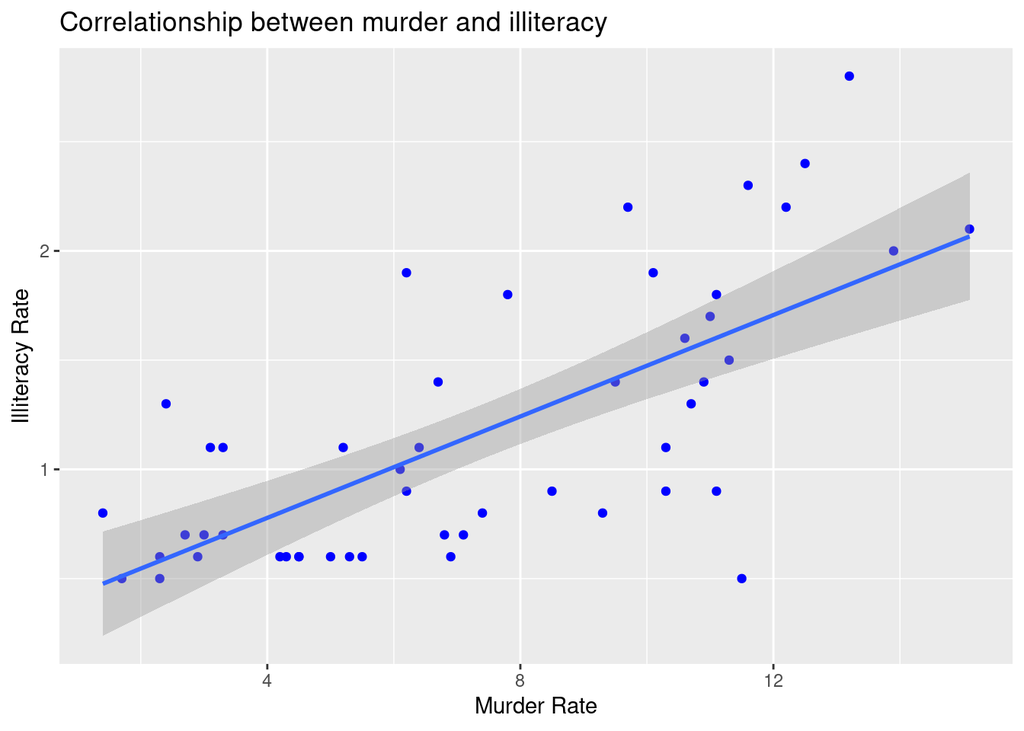

```r
ggplot(data= state_table)+ aes(x =state_table$Murder, y = state_table$Illiteracy) + geom_point(color="blue") + geom_smooth(method = "lm") + xlab("Murder Rate") + ylab("Illiteracy Rate") + ggtitle("Correlationship between murder and illiteracy")
```

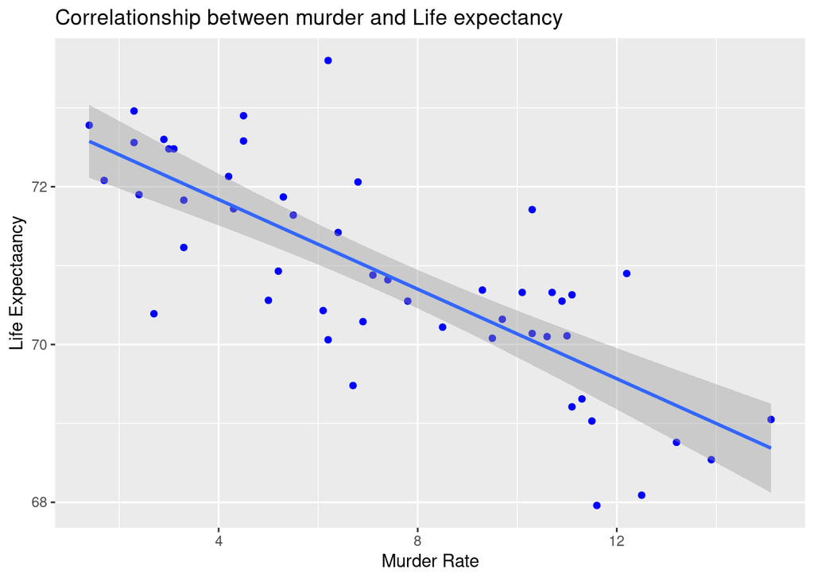

```r
ggplot(data= state_table)+ aes(x =state_table$Murder, y = state_table$`Life Exp`) + geom_point(color="blue") + geom_smooth(method = "lm") + xlab("Murder Rate") + ylab("Life Expectaancy") + ggtitle("Correlationship between murder and Life expectancy")
```

From our analysis we prove that Illiteracy has a positive bivariate correlation with murder as the slope of the smoohtening line shows and Life Expectancy has a negatice bivariate correlation with murder as the slope of the smoohtening line shows.

##### (c) How well do your smooth lines describe the variation you see in data?

Do you see any particular issues? Any features in the data that the straight line cannot capture? Note: we ask for your best judgement based on the figures, not any kind of specification tests.

There are some things we must keep in mind when using assuming a linear relationship to check bivariate relationships, since they may not always be accurate:- • Linear relationships can be skewed by outliers.We have some outliers in our data but not too many. • The two variables of interest may indeed be related, but just not in a linear fashion.But in our case they are linearly related. Source:investopedia.com/terms/d/data-smoothing.asp

##### (d) Develop a new research question of your own that you can address using the `state` dataset. Clearly state the question you are going to address. Provide at least one visualizations to support your exploration of this question. Discuss what you find.

Research Question: How is the murder rate related to the population of different states in our dataset.

First I will group the data into 3 categories 1) Lowly population 2) Moderate Population 3) High Population

```r
# cutting the data into 3 groups
population_factor<-cut(state_table$Population,breaks = 3,labels = c("Lowly Population","Moderate Population","High Population"))

state_table<-state_table %>% mutate(population_factor)
state_table
```

| Population | Income | Illiteracy | Life Exp | Murder | HS Grad | Frost | Area | Name | Longitude | Latitude | Region | Division | population_factor |
| --- | --- | --- | --- | --- | --- | --- | --- | --- | --- | --- | --- | --- | --- |
| 3615 | 3624 | 2.1 | 69.05 | 15.1 | 41.3 | 20 | 50708 | Alabama | -86.7509 | 32.5901 | South | East South Central | Lowly Population |
| 365 | 6315 | 1.5 | 69.31 | 11.3 | 66.7 | 152 | 566432 | Alaska | -127.2500 | 49.2500 | West | Pacific | Lowly Population |
| 2212 | 4530 | 1.8 | 70.55 | 7.8 | 58.1 | 15 | 113417 | Arizona | -111.6250 | 34.2192 | West | Mountain | Lowly Population |
| 2110 | 3378 | 1.9 | 70.66 | 10.1 | 39.9 | 65 | 51945 | Arkansas | -92.2992 | 34.7336 | South | West South Central | Lowly Population |
| 21198 | 5114 | 1.1 | 71.71 | 10.3 | 62.6 | 20 | 156361 | California | -119.7730 | 36.5341 | West | Pacific | High Population |
| 2541 | 4884 | 0.7 | 72.06 | 6.8 | 63.9 | 166 | 103766 | Colorado | -105.5130 | 38.6777 | West | Mountain | Lowly Population |
| 3100 | 5348 | 1.1 | 72.48 | 3.1 | 56.0 | 139 | 4862 | Connecticut | -72.3573 | 41.5928 | Northeast | New England | Lowly Population |
| 579 | 4809 | 0.9 | 70.06 | 6.2 | 54.6 | 103 | 1982 | Delaware | -74.9841 | 38.6777 | South | South Atlantic | Lowly Population |
| 8277 | 4815 | 1.3 | 70.66 | 10.7 | 52.6 | 11 | 54090 | Florida | -81.6850 | 27.8744 | South | South Atlantic | Moderate Population |
| 4931 | 4091 | 2.0 | 68.54 | 13.9 | 40.6 | 60 | 58073 | Georgia | -83.3736 | 32.3329 | South | South Atlantic | Lowly Population |

[output cut: 40 more lines]

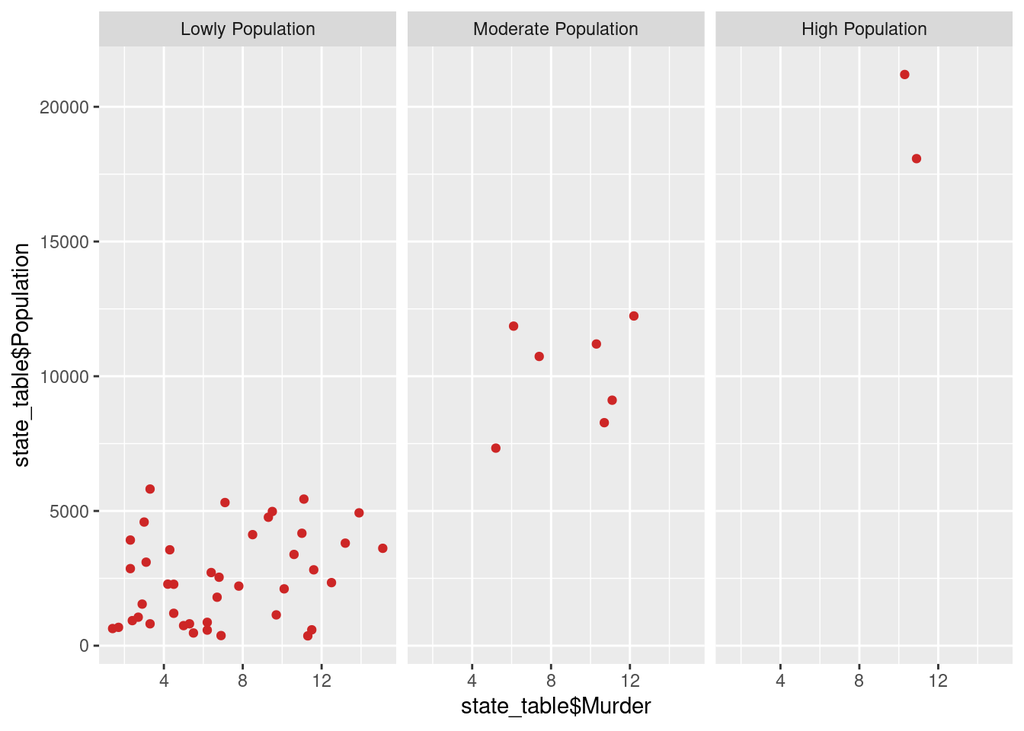

```r
ggplot(data = state_table) + aes(x = state_table$Murder,y = state_table$Population) + geom_point(color = "firebrick3")+ facet_wrap(~population_factor,ncol=3)
```

### Problem 2: Asking Data Science Questions: Crime and Educational Attainment

In Problem Set 3, you joined data about crimes and educational attainment. Here you will use this new combined dataset to examine questions around crimes in Seattle and the educational attainment of people living in the areas in which the crime occurred.

#### (a) Develop a Data Science Question

Develop your own question to address in this analysis. Your question should be specific and measurable, and it should be able to be addressed through a basic analysis of the crime dataset you compiled in Problem Set 3.

#### (b) Describe and Summarize

Briefly summarize the dataset, describing what data exists and its basic properties. Comment on any issues that need to be resolved before you can proceed with your analysis. Describing the data:-

```r
head(beatcrimecensus)
```

|  | Report.Number | Occurred.Date | Occurred.Time | Reported.Date | Reported.Time | Crime.Subcategory | Primary.Offense.Description | Precinct | Sector | Beat | Neighborhood | year | Location.1 | Latitude | Longitude | CTract | ctract | stateCode | countyCode | joincode | GEO.id2 | GEO.id | GEO.display.label | total | no_schooling | nursery_school | kindergarten | X1st_grade | X2nd_grade | … |
| --- | --- | --- | --- | --- | --- | --- | --- | --- | --- | --- | --- | --- | --- | --- | --- | --- | --- | --- | --- | --- | --- | --- | --- | --- | --- | --- | --- | --- | --- | --- |
| 1 | 20120000100012 | 2012-04-02 | 2040 | 04/03/2012 | 28 | NARCOTIC | NARC-POSSESS-MARIJU | WEST | K | K2 | PIONEER SQUARE | 2012 | (47.5998930290529, -122.326813620856) | 47.59989 | -122.3268 | 530330092001012 | 530330092001012 | 53 | 033 | 53033009200 | 53033009200 | 1400000US53033009200 | Census Tract 92, King County, Washington | 2529 | 56 | 0 | 0 | 0 | 0 | … |
| 2 | 20120000100035 | 2012-04-02 | 2100 | 04/02/2012 | 2103 | ROBBERY-COMMERCIAL | ROBBERY-BUSINESS-GUN | NORTH | B | B2 | BALLARD SOUTH | 2012 | (47.6790521901374, -122.391748391741) | 47.67905 | -122.3918 | 530330032001003 | 530330032001003 | 53 | 033 | 53033003200 | 53033003200 | 1400000US53033003200 | Census Tract 32, King County, Washington | 6896 | 26 | 0 | 0 | 0 | 0 | … |
| 3 | 20120000100055 | 2012-04-02 | 1930 | 04/02/2012 | 2126 | MOTOR VEHICLE THEFT | VEH-THEFT-AUTO | NORTH | J | J1 | BALLARD NORTH | 2012 | (47.676809900774, -122.337899655521) | 47.67681 | -122.3379 | 530330046001001 | 530330046001001 | 53 | 033 | 53033004600 | 53033004600 | 1400000US53033004600 | Census Tract 46, King County, Washington | 2806 | 17 | 0 | 0 | 0 | 0 | … |
| 4 | 20120000100062 | 2012-04-02 | 2144 | 04/02/2012 | 2144 | DUI | DUI-LIQUOR | EAST | E | E3 | CAPITOL HILL | 2012 | (47.603162336406, -122.319319689671) | 47.60316 | -122.3193 | 530330086003009 | 530330086003009 | 53 | 033 | 53033008600 | 53033008600 | 1400000US53033008600 | Census Tract 86, King County, Washington | 2477 | 100 | 0 | 44 | 0 | 0 | … |
| 5 | 20120000100092 | 2012-04-02 | 2218 | 04/02/2012 | 2218 | ROBBERY-RESIDENTIAL | ROBBERY-RESIDENCE-BODYFORCE | EAST | C | C2 | MADISON PARK | 2012 | (47.6192385752996, -122.313557430551) | 47.61924 | -122.3136 | 530330075002001 | 530330075002001 | 53 | 033 | 53033007500 | 53033007500 | 1400000US53033007500 | Census Tract 75, King County, Washington | 7239 | 27 | 0 | 1 | 0 | 0 | … |
| 6 | 20120000100102 | 2012-04-02 | 2229 | 04/02/2012 | 2229 | CAR PROWL | THEFT-CARPROWL | NORTH | U | U2 | UNIVERSITY | 2012 | (47.6585545300635, -122.30659481859) | 47.65855 | -122.3066 | 530330053023020 | 530330053023020 | 53 | 033 | 53033005302 | 53033005302 | 1400000US53033005302 | Census Tract 53.02, King County, Washington | 215 | 0 | 0 | 0 | 0 | 0 | … |

```r
names(beatcrimecensus)
```

```
##  [1] "Report.Number"
##  [2] "Occurred.Date"
##  [3] "Occurred.Time"
##  [4] "Reported.Date"
##  [5] "Reported.Time"
##  [6] "Crime.Subcategory"
##  [7] "Primary.Offense.Description"
##  [8] "Precinct"
##  [9] "Sector"
## [10] "Beat"
## [11] "Neighborhood"
## [12] "year"
## [13] "Location.1"
## [14] "Latitude"
## [15] "Longitude"
```

[output cut: 33 more lines]

The dataset we are using contains a record for each crime committed in Seattle, and is partitioned based on the “Beat” in which it occured. To understand the divisions in Seattle, I am explicitly pasting the meaning of three variables which seem important. Explanation for Precint, Sector, and Beats from the Seattle govt. website. . . “Seattle is divided into five geographic areas. Within those areas are the 5 precincts or police stations: North, East, South, West and Southwest. Precinct boundaries were determined through consideration of neighborhood boundaries, geographic and other natural boundaries. Each precinct contains smaller geographic areas called Sectors. There are 17 sectors total in the city. Each of these Sectors are divided into between 3 smaller sections called Beats (i.e. Ocean sector has three beats O1, O2, O3) These are the areas that individual patrol officers are assigned responsibility for.” Apart from variables pertaining to the crime itself, we have information about each Beat’s location and the education levels of the population in that beat. This fact is important as I am going to try and base my hypothesis around this.

Summarizing the main variable of interest:-

```r
#Showing the number of crimes in each beat
beat_total <- beatcrimecensus %>% group_by(Beat) %>% summarise(tot = n())

beat_total
```

| Beat | tot |
| --- | --- |
| B1 | 6048 |
| B2 | 6807 |
| B3 | 6821 |
| C1 | 4482 |
| C2 | 3830 |
| C3 | 3817 |
| D1 | 6354 |
| D2 | 5941 |
| D3 | 5189 |
| E1 | 5824 |

[output cut: 41 more lines]

#### (c) Data Analysis

Use the dataset to provide empirical evidence that addressed your question from part (a). Discuss your results. Provide at least one visualization to support your narrative.

```r
#filtering education data for each beat and then selecting the education columns
edubeat <- beatcrimecensus[,c(10,26:46)]%>% group_by(Beat)%>% summarise_all(min)
edubeat
```

| Beat | nursery_school | kindergarten | X1st_grade | X2nd_grade | X3rd_grade | X4th_grade | X5th_grade | X6th_grade | X7th_grade | X8th_grade | X9th_grade | X10th_grade | X11th_grade | X12th_grade_no_diploma | high_school_diploma | ged_or_alternative_credential | some_college_less_than_1_year | some_college_1_or_more_years_no_degree | associates_degree | bachelors_degree | masters_degree |
| --- | --- | --- | --- | --- | --- | --- | --- | --- | --- | --- | --- | --- | --- | --- | --- | --- | --- | --- | --- | --- | --- |
| B1 | 0 | 0 | 0 | 0 | 15 | 0 | 0 | 0 | 0 | 33 | 18 | 110 | 20 | 34 | 472 | 100 | 245 | 536 | 310 | 1301 | 760 |
| B2 | 0 | 0 | 0 | 0 | 0 | 0 | 0 | 0 | 0 | 15 | 0 | 0 | 15 | 0 | 348 | 102 | 205 | 776 | 444 | 3000 | 1433 |
| B3 | 0 | 0 | 0 | 0 | 0 | 0 | 0 | 0 | 0 | 0 | 17 | 0 | 32 | 16 | 196 | 88 | 134 | 447 | 111 | 1310 | 864 |
| C1 | 0 | 0 | 0 | 0 | 0 | 0 | 0 | 0 | 1 | 0 | 2 | 0 | 20 | 0 | 136 | 15 | 145 | 416 | 204 | 1620 | 692 |
| C2 | 0 | 1 | 0 | 0 | 27 | 0 | 0 | 0 | 0 | 0 | 1 | 0 | 0 | 28 | 286 | 26 | 224 | 840 | 570 | 3256 | 1252 |
| C3 | 0 | 0 | 0 | 0 | 0 | 0 | 0 | 0 | 0 | 5 | 20 | 18 | 0 | 0 | 54 | 15 | 161 | 401 | 212 | 1822 | 915 |
| D1 | 0 | 0 | 0 | 0 | 0 | 0 | 0 | 8 | 0 | 0 | 30 | 33 | 0 | 0 | 236 | 66 | 249 | 733 | 460 | 2849 | 2161 |
| D2 | 0 | 0 | 0 | 0 | 0 | 0 | 0 | 3 | 0 | 4 | 0 | 0 | 0 | 0 | 160 | 2 | 128 | 289 | 276 | 1554 | 602 |
| D3 | 0 | 0 | 0 | 0 | 60 | 0 | 0 | 10 | 0 | 8 | 4 | 14 | 14 | 30 | 202 | 118 | 129 | 377 | 167 | 992 | 358 |
| E1 | 0 | 0 | 0 | 0 | 0 | 0 | 0 | 0 | 0 | 0 | 8 | 7 | 72 | 17 | 372 | 153 | 155 | 788 | 220 | 1613 | 699 |

[output cut: 41 more lines]

#Calculating education level in each beat and then joining with total beats

```r
educlassbeat <- edubeat%>% mutate(low_education =rowSums(edubeat[,2:11])/rowSums(edubeat[,2:22]),medium_education =rowSums(edubeat[,12:16])/rowSums(edubeat[,2:22]),high_education =rowSums(edubeat[,17:22])/rowSums(edubeat[,2:22]))

educrimebeat <-left_join(beat_total,educlassbeat, by ="Beat")
educrimebeat
```

| Beat | tot | nursery_school | kindergarten | X1st_grade | X2nd_grade | X3rd_grade | X4th_grade | X5th_grade | X6th_grade | X7th_grade | X8th_grade | X9th_grade | X10th_grade | X11th_grade | X12th_grade_no_diploma | high_school_diploma | ged_or_alternative_credential | some_college_less_than_1_year | some_college_1_or_more_years_no_degree | associates_degree | bachelors_degree | masters_degree | low_education | medium_education | high_education |
| --- | --- | --- | --- | --- | --- | --- | --- | --- | --- | --- | --- | --- | --- | --- | --- | --- | --- | --- | --- | --- | --- | --- | --- | --- | --- |
| B1 | 6048 | 0 | 0 | 0 | 0 | 15 | 0 | 0 | 0 | 0 | 33 | 18 | 110 | 20 | 34 | 472 | 100 | 245 | 536 | 310 | 1301 | 760 | 0.0121396055 | 0.16540212 | 0.8224583 |
| B2 | 6807 | 0 | 0 | 0 | 0 | 0 | 0 | 0 | 0 | 0 | 15 | 0 | 0 | 15 | 0 | 348 | 102 | 205 | 776 | 444 | 3000 | 1433 | 0.0023666772 | 0.05727359 | 0.9403597 |
| B3 | 6821 | 0 | 0 | 0 | 0 | 0 | 0 | 0 | 0 | 0 | 0 | 17 | 0 | 32 | 16 | 196 | 88 | 134 | 447 | 111 | 1310 | 864 | 0.0000000000 | 0.08118196 | 0.9188180 |
| C1 | 4482 | 0 | 0 | 0 | 0 | 0 | 0 | 0 | 0 | 1 | 0 | 2 | 0 | 20 | 0 | 136 | 15 | 145 | 416 | 204 | 1620 | 692 | 0.0003075977 | 0.04860043 | 0.9510920 |
| C2 | 3830 | 0 | 1 | 0 | 0 | 27 | 0 | 0 | 0 | 0 | 0 | 1 | 0 | 0 | 28 | 286 | 26 | 224 | 840 | 570 | 3256 | 1252 | 0.0043004147 | 0.04837967 | 0.9473199 |
| C3 | 3817 | 0 | 0 | 0 | 0 | 0 | 0 | 0 | 0 | 0 | 5 | 20 | 18 | 0 | 0 | 54 | 15 | 161 | 401 | 212 | 1822 | 915 | 0.0013800718 | 0.02539332 | 0.9732266 |
| D1 | 6354 | 0 | 0 | 0 | 0 | 0 | 0 | 0 | 8 | 0 | 0 | 30 | 33 | 0 | 0 | 236 | 66 | 249 | 733 | 460 | 2849 | 2161 | 0.0011721612 | 0.04380952 | 0.9550183 |
| D2 | 5941 | 0 | 0 | 0 | 0 | 0 | 0 | 0 | 3 | 0 | 4 | 0 | 0 | 0 | 0 | 160 | 2 | 128 | 289 | 276 | 1554 | 602 | 0.0023194168 | 0.05301524 | 0.9446653 |
| D3 | 5189 | 0 | 0 | 0 | 0 | 60 | 0 | 0 | 10 | 0 | 8 | 4 | 14 | 14 | 30 | 202 | 118 | 129 | 377 | 167 | 992 | 358 | 0.0314136126 | 0.10632300 | 0.8622634 |
| E1 | 5824 | 0 | 0 | 0 | 0 | 0 | 0 | 0 | 0 | 0 | 0 | 8 | 7 | 72 | 17 | 372 | 153 | 155 | 788 | 220 | 1613 | 699 | 0.0000000000 | 0.11598441 | 0.8840156 |

[output cut: 41 more lines]

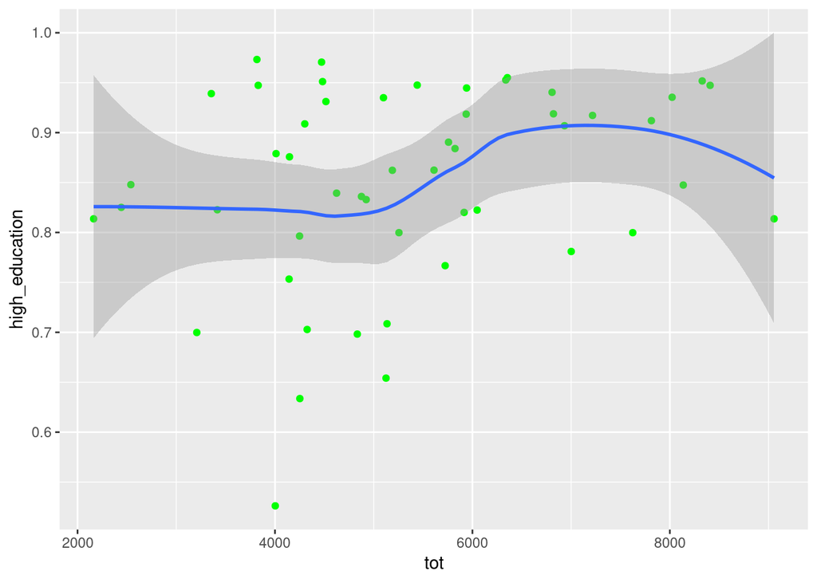

```r
educrimebeat%>% ggplot(aes(x=tot, y= high_education))+geom_point(color="green")+geom_smooth()
```

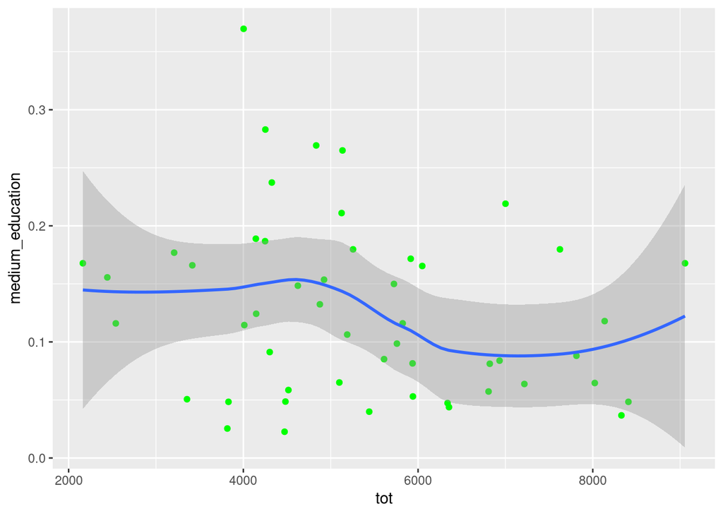

```r
educrimebeat%>% ggplot(aes(x=tot, y= medium_education))+geom_point(color="green")+geom_smooth()
```

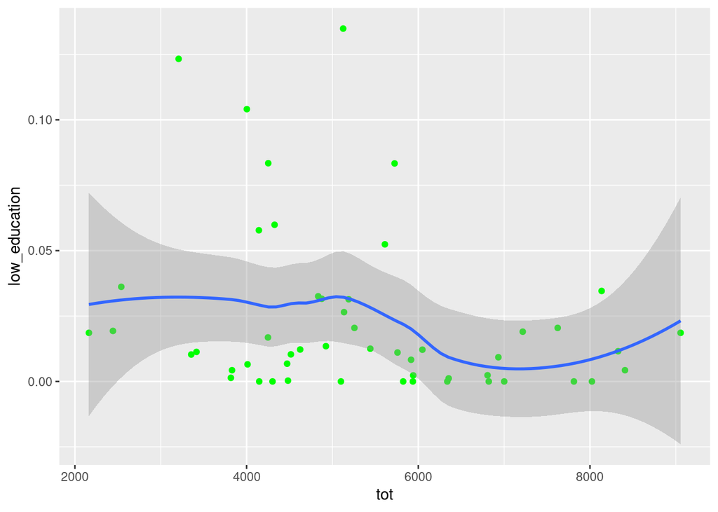

```r
educrimebeat%>% ggplot(aes(x=tot, y= low_education))+geom_point(color="green")+geom_smooth()
```

Comment the questions (and answers) in this analysis. Were you able to answer all of these questions? Are all questions well defined? Is the data good enough to answer all these?

### Problem 3: Sampling with and without Replacement

In the following situations assume that half of the specified population is wearing a cap and half are not.

Hint: make sure you have read Openintro Statistics (OIS) 3.3 (p 112)

##### (a) Sampling in a small room

Suppose you’re sampling (uniformly) from a room with 10 people. What is the probability of sampling two persons with cap when sampling with replacement? What is the probability when sampling without replacement?

```r
# with replacement : Can be picked again# Since 5 out of 10 people have cap in the sample.
#The probability of picking someone with cap is
(5/10)*(5/10)
```

```
## [1] 0.25
```

```r
# without replacement: can not be picked again.# In this case probably for second pick will change,

#since First person with cap who is already picked, can not be picked again.

(5/10)*(4/9)
```

```
## [1] 0.2222222
```

##### (b) Sampling in a big stadium

Now suppose you’re sampling from a stadium with 10,000 people. What is the probability of sampling two persons with cap when sampling with replacement? What is the probability when sampling without replacement?

```r
#with replacement : Can be picked again
(5000/10000)*(5000/10000)
```

```
## [1] 0.25
```

```r
#without replacement: can not be picked again
(5000/10000)*(4999/9999)
```

```
## [1] 0.249975
```

##### (c) We often treat individuals who are sampled from a large population as independent. Using your findings from parts (a) and (b), explain whether or not this assumption is reasonable.

1)When we have a small group of 10, there was larger variation in probability of getting two persons with capsin cases of with and without replacement. 2)Although in larger population of 10000, the probablities of getting two persons with capsin both cases of with and without replacement were nearly same.

Concluding it’s an OK assumption to treat indiviuals sampled from a large population as independent for analytical purposes.